# Praca domowa 2

Grzegorz Zakrzewski

## Poprawiana wizualizacja

Poprawiana wizualizacja to wykres opublikowany przez TVP w wydaniu Wiadomości z godziny 19:30 dnia 28.10.2021r.

[figure not shown]

### Źródło:

https://wiadomosci.tvp.pl/56266342/28102021-1930

Timestamp: 9:21

Ten sam materiał, lecz na YouTube:

https://www.youtube.com/watch?v=LIwxGI6i22I&t=547s

## Tworzona wizualizacja

TVP jako źródło swoich danych podaje portal [Global Carbon Atlas](http://globalcarbonatlas.org/en/CO2-emissions). Z tej strony można pobrać dane dotyczące emisji CO2 dla każdego kraju w latach 1960-2019. Te dane **nieznacznie się różnią** od danych prezentowanych przez TVP, jednak mimo wszystko je wykorzystam.

### Kod

Pliku z danymi nie zamieszam, jednak na końcu raportu znajduje się rysunek przedstawiający strukturę danych.

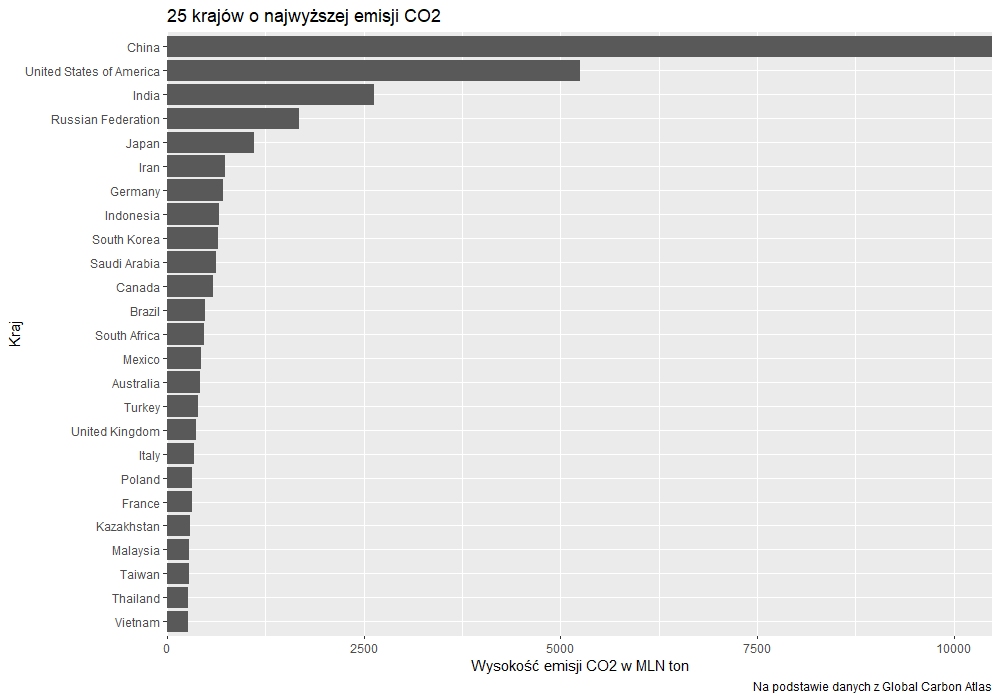

```r
df <- readr::read_csv("global_co2.csv");

library(dplyr);
library(tidyr);
library(ggplot2);

df %>%
  filter(Year == 2019) %>%
  pivot_longer(!Year, names_to = "Country", values_to = "MtCO2") %>%
  mutate(Country = forcats::fct_reorder(Country, MtCO2)) %>%
  slice_max(MtCO2, n = 25) %>%
  ggplot(aes(x = MtCO2, y = Country)) +
  geom_col() +
  scale_x_continuous(expand = c(0, 0)) +
  labs(
    title = "25 krajów o najwyższej emisji CO2",
    x = "Wysokość emisji CO2 w MLN ton",
    y = "Kraj",
    caption = "Na podstawie danych z Global Carbon Atlas"
  )
```

### Dlaczego ten wykres jest lepszy niż oryginalny?

- słupki są 2d, dlatego jest lepiej czytelny; słupki na oryginalnym wykresie mają “delikatny” efekt 3d;
- słupki nie zawierają etykiet, które swoim rozmiarem mogą zaburzyć porównywanie ich wysokości;
- dodana oś pozioma ułatwia porównywanie wartości;
- wykres oryginalny traci na znaczeniu bez komentarza reportera; nie jesteśmy w stanie sprawdzić, na którym miejscu faktycznie znajduje się Francja;
- wykres oryginalny zestawia tylko dziewięć wybranych krajów; zaciemnia to sytuację: nie widzimy, czy Niemcy faktycznie są tak daleko przed Francją w rankingu.

### Jak wyglądały dane z Global Carbon Atlas?

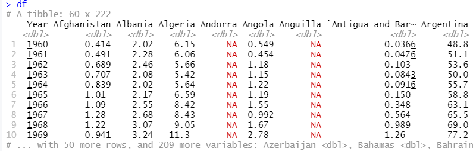